# Laboration 3

Andrew Dean & Ekaterina Kershinskaia

2026-10-25

# Sammanfattning

Syftet med laborationen är att använda simuleringar i $R$ för att illustrera två av de viktigaste gränsvärdessatserna i sannolikhetsteorin: Stora talens lag och Centrala gränsvärdessatsen.

# Uppgift 1

Stora talens lag säger att medelvärdet närmar sig det sanna väntevärdet när antalet observationer ökar. För att illustrera detta börjar vi med att skapa ett dataset med $n=300$ slumptal från en exponentialfördelning med väntevärde $m=1$, och undersöker hur det kumulativa medelvärdet utvecklas när antalet observationer ökar.

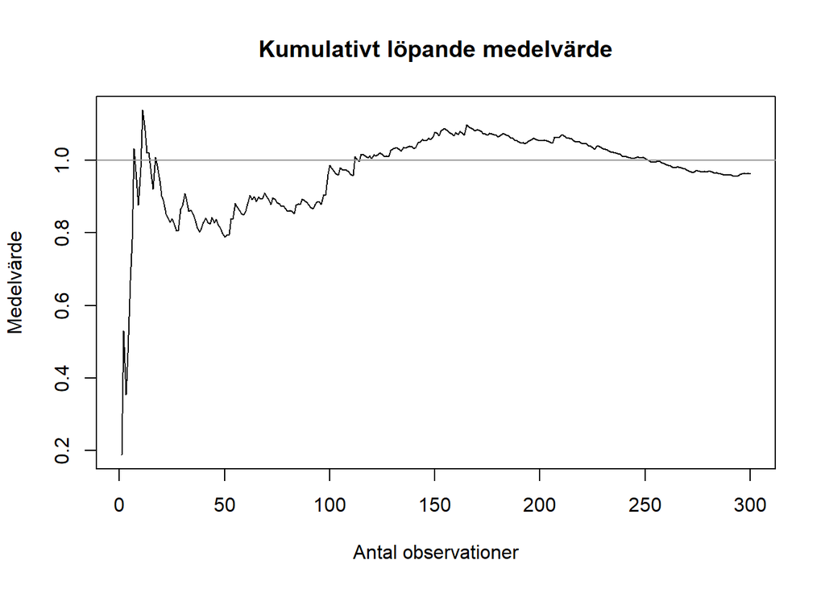

Kumulativt medelvärde för 300 slumptal från en exponentialfördelning med väntevärde 1.

```r
# Först ger vi ett "frö" (seed) till slumptalsgeneratorn genom funktionen set.seed
# Detta gör att vi får exakt samma slumptal varje gång vi kör koden.
set.seed(19980226)

m <- 1 # väntevärde
slumptal <- rexp(300, rate = 1/m) # rate = 1 / väntevärde

# lista med kumulativa medelvärden för de första i observationerna
medel <- cumsum(slumptal) / 1:length(slumptal)

plot_medel <- function(medel, m) {
  plot(medel,
  type = "l", # plotta en linje
  main = "Kumulativt löpande medelvärde",
  ylab = "Medelvärde",
  xlab = "Antal observationer")
  abline(a = m, b = 0, col = "gray60") # Horisontell linje vid väntevärdet m
}

plot_medel(medel, m)
```

Vi observerar i figur 1 att det kumulativa medelvärdet varierar mycket i början men verkar närma sig det teoretiska väntevärdet $m=1$ när antalet observationer ökar. Och samma mönster gäller även när vi använder ett annat slumptalsfrö (se figur 2).

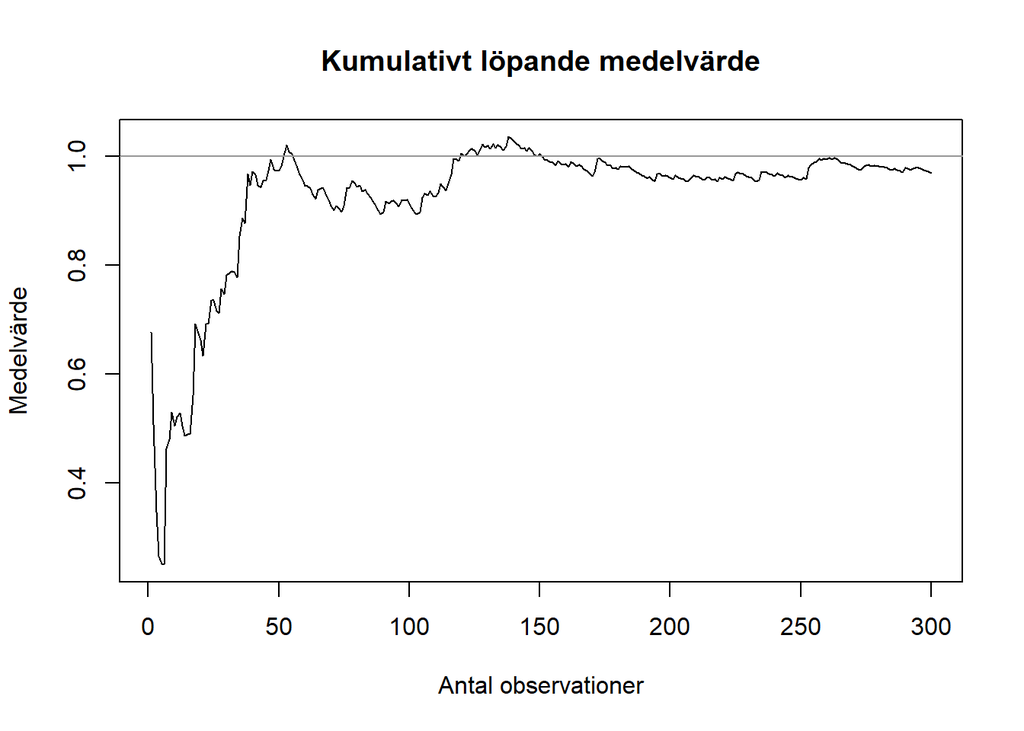

Kumulativt medelvärde för 300 slumptal från en exponentialfördelning med väntevärde 1, genererade med ett annat slumptalsfrö.

```r
set.seed(19981207) # annat frö
slumptal2 <- rexp(300, rate = 1/m) # samma m
medel2 <- cumsum(slumptal2) / 1:length(slumptal2)
plot_medel(medel2, m)
```

Tendensen syns ännu tydligare när vi ökar antalet observationer till $n=1000$ (se figur 3).

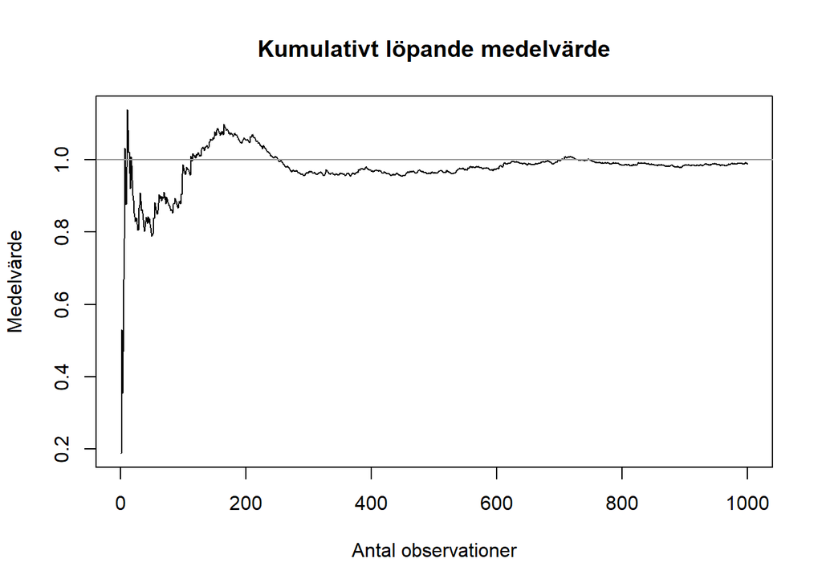

Kumulativt medelvärde för 1 000 slumptal från en exponentialfördelning med väntevärde 1.

```r
set.seed(19980226)
slumptal3 <- rexp(1000, rate = 1/m)
medel3 <- cumsum(slumptal3) / 1:length(slumptal3)
plot_medel(medel3, m)
```

Sedan genererar vi $n=1000$ slumptal från en exponentialfördelning med ett annat väntevärde $m_2=2$, och ser att medelvärdet nu närmar sig det nya väntevärdet (se figur 4).

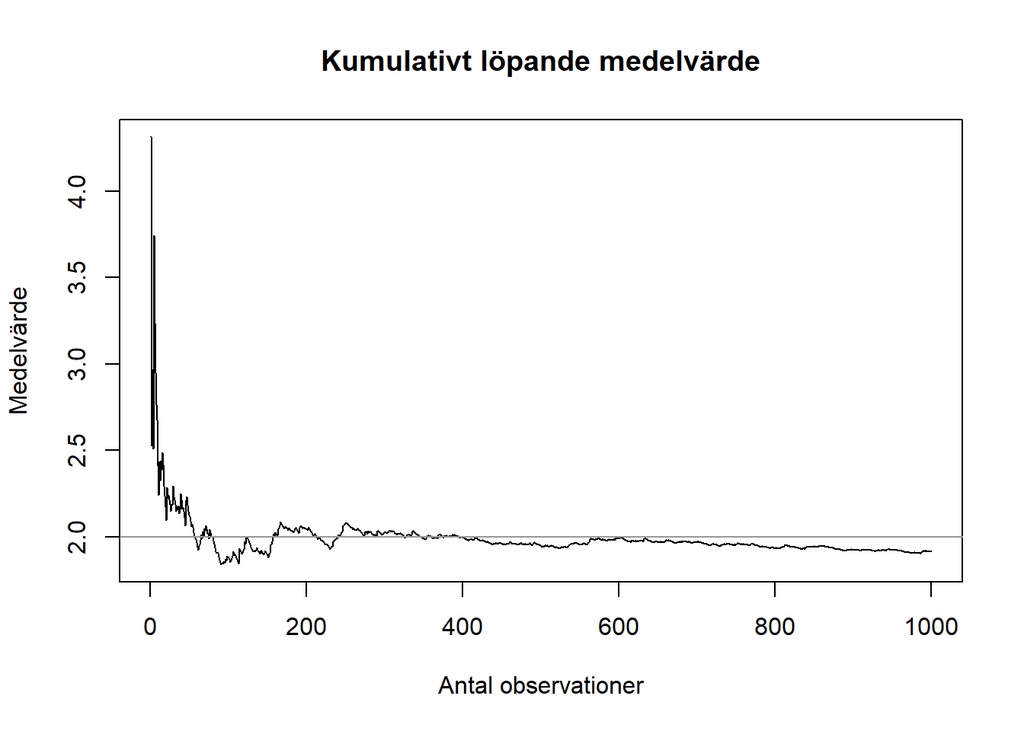

Kumulativt medelvärde för 1 000 slumptal från en exponentialfördelning med väntevärde 2.

```r
m2 <- 2
slumptal4 <- rexp(1000, rate = 1/m2)
medel4 <- cumsum(slumptal4) / 1:length(slumptal4)
plot_medel(medel4, m2)
```

Slutligen undersöker vi om samma princip gäller för slumptal från standardnormalfördelningen, vars teoretiska väntevärde är 0.

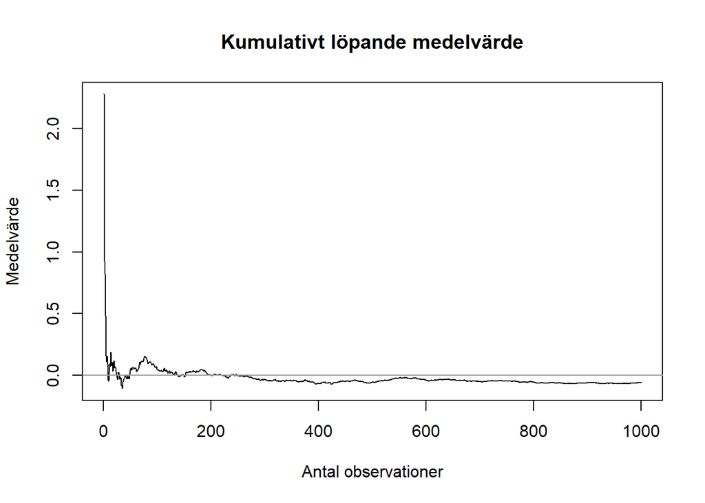

Kumulativt medelvärde för 1 000 slumptal från standardnormalfördelningen $\mathcal{N}(0, 1)$.

```r
slumptal5 <- rnorm(1000)
medel5 <- cumsum(slumptal5) / 1:length(slumptal5)
plot_medel(medel5, 0)
```

Även för standardnormalfördelningen verkar det kumulativa medelvärdet närma sig det teoretiska väntevärdet (se figur 5).

Vi ser att medelvärdet konvergerar mot det teoretiska väntevärdet när antalet observationer ökar, för både exponentialfördelningen och standardnormalfördelningen. Resultaten stämmer därmed överens med Stora talens lag.

# Uppgift 2

Centrala gränsvärdessatsen säger att det standardiserade stickprovsmedelvärdet av $n$ stycken oberoende och likafördelade observationer (betecknade $X_1, X_2, ..., X_n$, med $\mathbb{E}[X_k] = \mu, \operatorname{Var}(X_k)=\sigma^2 \; (0<\sigma<\infty), \forall{k}$) närmar sig en standardnormalfördelning då $n \to \infty$, och alltså kan approximeras av en normalfördelning då $n$ är stort.

Mer specifikt:

$\mathbb{P} \left(\frac{\sqrt{n}}{\sigma}(\bar{X}_n - \mu) \leq z \right) = \mathbb{P} \left(\frac{S_n - \mu n}{\sigma \sqrt{n}} \leq z \right) \to \Phi (z) \quad$ då $n \to \infty, \quad z \in \mathbb{R}$

där $\Phi (z) = \mathbb{P}(Z \leq z), \; Z \sim \mathcal{N}(0, 1) \;$ är fördelningsfunktionen för standardnormalfördelningen,

och $S_n = \sum_{k=1}^{n}{X_k}, \; \bar{X}_n = \frac{S_n}{n}$.

Med andra ord blir summan av många oberoende observationer approximativt normalfördelad, oavsett hur de enskilda observationer är fördelade.

```r
plot_sum <- function(n, matrix, mu, sigma2, distribution_name) {
  summa <- colSums(matrix)
  stand <- (summa - n * mu) / sqrt(n * sigma2) # standardisera observationerna

  hist(stand,
      main = sprintf("Standardiserade observationer (%s, n=%d)", distribution_name, n),
      ylab = "Antal",
      xlab = "Värde")
}

plot_uniform_sum <- function(n, M) {
  likf_matris <- matrix(runif(n * M), nrow = n, ncol = M)
  plot_sum(n, likf_matris, 1/2, 1/12, "likformig")
}

plot_exponential_sum <- function(n, M) {
  exp_matris <- matrix(rexp(n * M), nrow = n, ncol = M)
  plot_sum(n, exp_matris, 1, 1, "exponential")
}
```

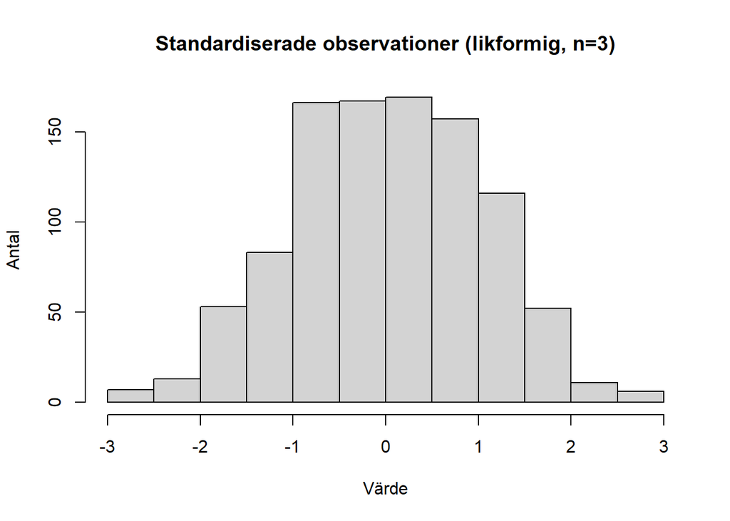

Standardiserade summor av $n=3$ observationer från en likformig fördelning.

```r
set.seed(19961111)
plot_uniform_sum(3, 1000)
```

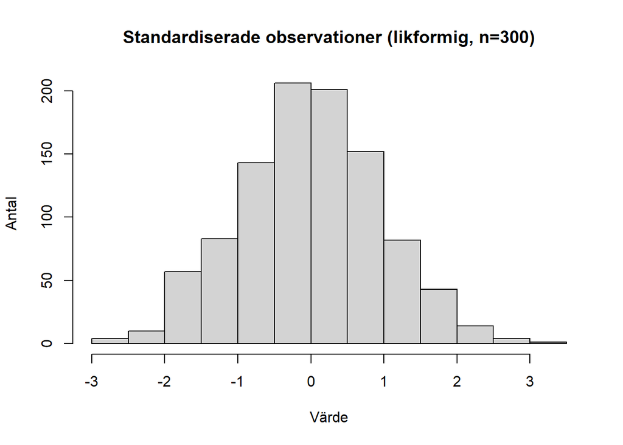

Standardiserade summor av $n=300$ observationer från en likformig fördelning.

```r
set.seed(19990123)
plot_uniform_sum(300, 1000)
```

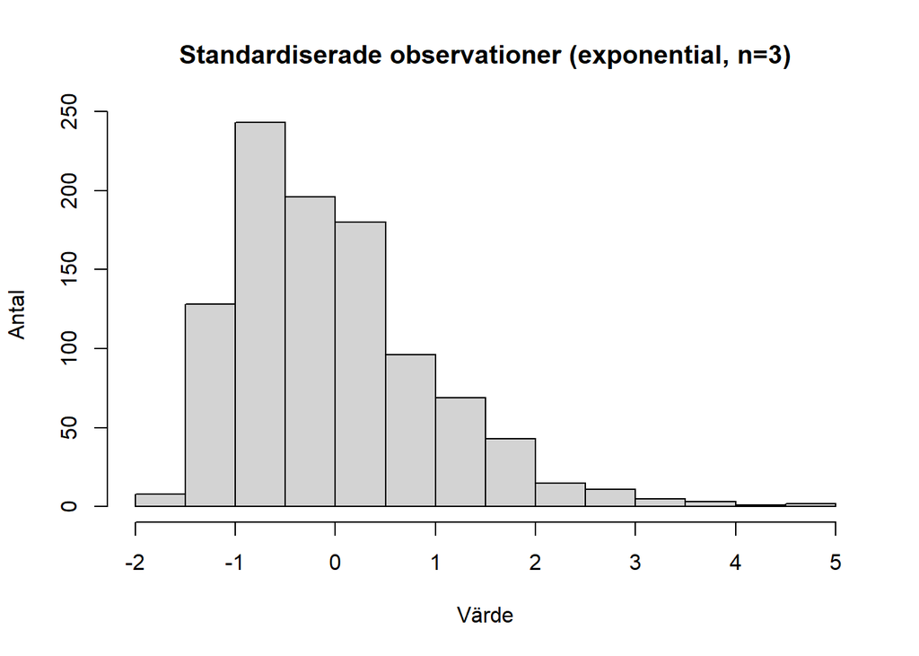

Standardiserade summor av $n=3$ observationer från en exponentialfördelning.

```r
set.seed(20020220)
plot_exponential_sum(3, 1000)
```

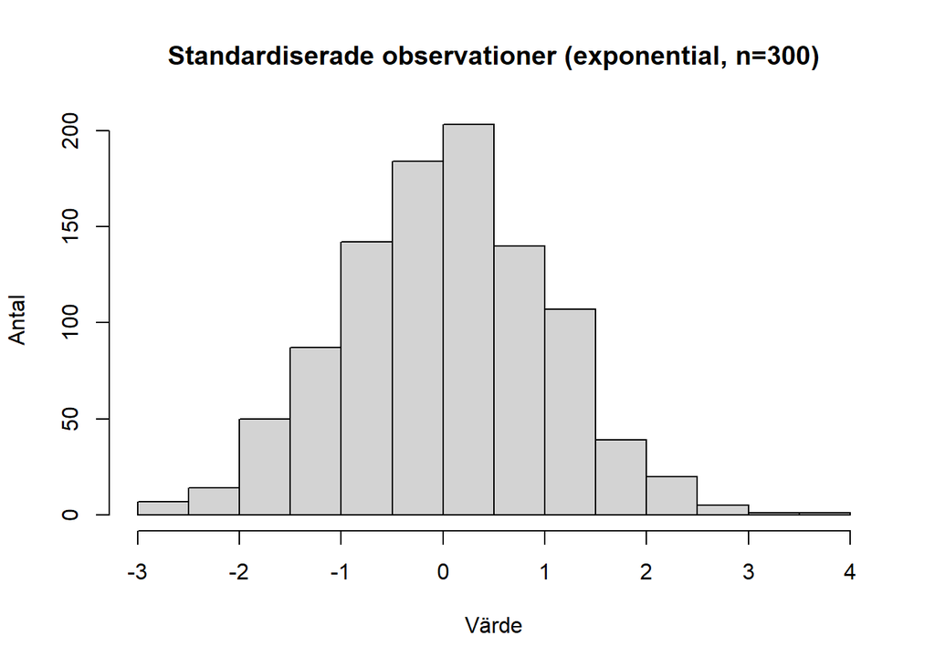

Standardiserade summor av $n=300$ observationer från en exponentialfördelning.

```r
set.seed(20000706)
plot_exponential_sum(300, 1000)
```

Den standardiserade summan av likformiga slumptal med $n=3$ (se figur 6) börjar se ut som en normalfördelning, med en synlig “topp”, men det ser fortfarande ganska “platt” ut i mitten.

När vi tar ett större värde på $n$ med $n=300$ (se figur 7) ser fördelningen mycket mer som en standardnormalfördelning ut, med den klassiska klockformen.

För de exponentialfördelade slumptalen gäller samma sak. Den standardiserade summan av exponentialfördelade slumptal med $n=3$ (se figur 8) har också en synlig “topp” i mitten, men det är fortfarande tydligt högerskev.

När vi tar $n=300$ i stället (se figur 9) ser fördelningen mycket mer standardnormalfördelad ut, men kanske fortfarande lite högerskev.

Det här stämmer överens med det som centrala gränsvärdessatsen säger: fördelning för de standardiserade summorna av observationer kan approximeras av en standardnormalfördelning, särskilt då $n$ blir stort.